# R Notebook

# all r1

PC13 separates a small number of contaminating Hbb-b1+ cells. Remove these cells from further analysis.

```r
cordir='all_r1/'
system(paste0('mkdir ',cordir));
system(paste0('mkdir ',file.path(cordir,'biplots')));


dt.pca = copy(dt.fv1_NS.good)
setkey(dt.pca)

n.pcs = 15
pca.d1 <- dimplots.pca.lowMem(dt.pca,cell.info,cordir,suffix='',max.genes = 30,ncp=n.pcs,
                              min.cells.detect=1,n.cores = 8)
plot.ggpairs.wExptCols(cell.info,dir=cordir,suffix='',num.pcs = n.pcs,height=25,width=25,sigType = 'Sig',annot.expt = F)

# remove some hemoglobin-high RBC precursors
pc.scores = fread(paste0(cordir, 'PC_allscores.csv'))
dt.pca.2 = merge(dt.pca[gene %in% c('Hbb-b1','Pecam1')],
                 pc.scores,
                 by='cell.name')


cutoff.point <- 0.3
if(with(dt.pca.2[gene=='Hbb-b1'], cor(log10.cpm, PC13.score)) < 0) cutoff.point <- -cutoff.point

ggplot(dt.pca.2, aes(PC13.pos, PC13.neg, color = log10.cpm)) + geom_point() +
  geom_abline(intercept = -cutoff.point) +
  scale_color_gradientn(colours=brewer.pal(9,'YlOrBr')[3:9]) +
  facet_wrap(~gene)+
  coord_fixed()
ggsave('all_r1/all_r1_hbbHi_separation.pdf',height = 3, width = 4)

if(cutoff.point > 0){
  cells.hbb.hi = pc.scores[ PC13.score > cutoff.point, cell.name]
} else{
    cells.hbb.hi = pc.scores[ PC13.score < cutoff.point, cell.name]
}

save(cells.hbb.hi, file = 'all_r1/cells_hbb_hi.RData')
write.table(cells.hbb.hi, file = 'all_r1/cells_hbb_hi.txt')
```

# all r2 (endocardial vs Aplnr)

2. rPCA, 15 PCs, all genes minus cell cycle (noCC). (endocard_refine_r1)

1. ```
   PC15 and PC2 separate a group of Gpr126+ endocardial cells that appears continuous with the Kcne- groups of cells.
   ```

2. ```
   Remove the Kcne+ group to further refine the Gpr126+ population (PC2 > 0.2)
   ```

```r
rm(list=ls()[ls() %like% 'cells.*'])
cordir='all_r2/'
system(paste0('mkdir ',cordir));
system(paste0('mkdir ',file.path(cordir,'biplots')));

load('all_r1/cells_hbb_hi.RData')

dt.pca = dt.fv1_NS.good[!cell.name %in% cells.hbb.hi][!gene %in% genes.cc]
setkey(dt.pca)

n.pcs = 15
# pca.d1 <- dimplots.pca.lowMem(dt.pca,cell.info,cordir,suffix='',max.genes = 30,ncp=n.pcs,
#                               min.cells.detect=1,n.cores = 8)
# plot.ggpairs.wExptCols(cell.info,dir=cordir,suffix='',num.pcs = n.pcs,height=25,width=25,sigType = 'Sig',annot.expt = F)
#
# make.facet.biplots(dt.pca,c(paste0('PC',1),paste0('PC',15)),cordir,size=1.5, plot.pdf = T,
#                    custom.genes = c('Aplnr','Smoc1','Pdgfra','A2m','Fbln2','Fbln5','Sfrp2','Kcne3','Gja4',
#                                     'Cxcr7','Gja5'),height = 6, width = 9)
# # remove coronary cells
pc.scores = fread(paste0(cordir, 'PC_allscores.csv'))
dt.pca.2 = merge(dt.pca[gene %in% c('Kcne3','Aplnr','Smoc1','Gpr126')],
                 pc.scores,
                 by='cell.name')

cutoff.point <- 0.18
if(with(dt.pca.2[gene=='Kcne3'], cor(log10.cpm, PC1.score)) < 0) cutoff.point <- -cutoff.point

ggplot(dt.pca.2, aes(PC1.score, PC15.score, color = log10.cpm)) +
  geom_point(size=.7) +
  geom_vline(xintercept = cutoff.point) +
  scale_color_gradientn(colours=brewer.pal(9,'YlOrBr')[3:9]) +
  coord_fixed() +
  facet_wrap(~gene)

ggsave('all_r2/cells_kcne3_all_r2_separation.pdf',height = 3, width = 4)

if(cutoff.point > 0){
cells.kcne3.all_r2 = pc.scores[ PC1.score > cutoff.point, cell.name]
} else{
cells.kcne3.all_r2 = pc.scores[ PC1.score < cutoff.point, cell.name]
}

save(cells.kcne3.all_r2, file = 'all_r2/cells_kcne3_all_r2.RData')
write.table(cells.kcne3.all_r2, file = 'all_r2/cells_kcne3_all_r2.txt')

plt=with(pc.scores, plot(PC1.score, PC15.score, pch = 20)) +
  with(pc.scores[!cell.name %in% cells.kcne3.all_r2],points(PC1.score, PC15.score, col = 'green', pch = 20 ))
plt
pdf('all_r2/all_r2_separation_verification.pdf', height = 4, width = 4)
plt
dev.off()
```

# endocard refine 1

3. rPCA, 15 PCs, noCC (endocard_refine_r2_v2).

1. ```
   PC2 and PC5 separate the Gpr126+ population from the Cldn11+ population.
   ```

2. ```
   Gpr126+ population appears continuous with the Apln-, PC5-high part of the Cldn11+ population.
   ```

3. ```
   Remove the Apln+ population (PC2 > -0.1 and PC5 < -0.1) to further refine the Gpr126+ population.
   ```

```r
cordir='endocard_refine_r1/'
system(paste0('mkdir ',cordir));
system(paste0('mkdir ',file.path(cordir,'biplots')));

load('all_r1/cells_hbb_hi.RData')
load('all_r2/cells_kcne3_all_r2.RData')

dt.pca = dt.fv1_NS.good[!cell.name %in% c(cells.hbb.hi, cells.kcne3.all_r2)]
dt.pca = dt.pca[!gene %in% genes.cc]
setkey(dt.pca)

n.pcs = 15
pca.d1 <- dimplots.pca.lowMem(dt.pca,cell.info,cordir,suffix='',max.genes = 30,ncp=n.pcs,
                              min.cells.detect=1,n.cores = 8)
plot.ggpairs.wExptCols(cell.info,dir=cordir,suffix='',num.pcs = n.pcs,height=25,width=25,sigType = 'Sig',annot.expt = F)

make.facet.biplots(dt.pca,c(paste0('PC',2),paste0('PC',15)),cordir,size=1.5, plot.pdf = T,num.genes = 10)

 # Further refinement of endocardial population
pc.scores = fread(paste0(cordir, 'PC_allscores.csv'))
dt.pca.2 = merge(dt.pca[gene %in% c('Pdgfra','Fbln2','Itih3','Kcne3')],
                 pc.scores, by='cell.name')

cutoff.point <- 0.2
if(with(dt.pca.2[gene=='Kcne3'], cor(log10.cpm, PC2.score)) < 0) cutoff.point <- -cutoff.point

ggplot(dt.pca.2, aes(PC2.score, PC15.score, color = log10.cpm)) + geom_point(size = .7) +
  scale_color_gradientn(colours=brewer.pal(9,'YlOrBr')[3:9]) +
  facet_wrap(~gene) + geom_vline(xintercept = cutoff.point) +
  coord_fixed()
ggsave('endocard_refine_r1/endocard_refine_r1_separation.pdf',height = 6, width = 9)

if(cutoff.point > 0){
  cells.endocardRefine.r1.v2 = pc.scores[ PC2.score < cutoff.point, cell.name]
} else{
  cells.endocardRefine.r1.v2 = pc.scores[ PC2.score > cutoff.point, cell.name]
}
cells.endocardRefine.r1.v2 = pc.scores[ PC2.score < cutoff.point, cell.name]

save(cells.endocardRefine.r1.v2, file = 'endocard_refine_r1/cells_endocard_refine_r1.RData')
write.table(cells.endocardRefine.r1.v2, file = 'endocard_refine_r1/cells_endocard_refine_r1.txt')


plt=with(pc.scores, plot(PC2.score, PC15.score, pch = 20)) +
  with(pc.scores[cell.name %in% cells.endocardRefine.r1.v2],points(PC2.score, PC15.score, col = 'green', pch = 20 ))
plt
pdf('endocard_refine_r1/endocard_refine_r1_separation_verification.pdf', height = 4, width = 4)
plt
dev.off()
```

# endocard refine 2 (remove Aplnr+ population)

```r
cordir='endocard_refine_r2/'
system(paste0('mkdir ',cordir));
system(paste0('mkdir ',file.path(cordir,'biplots')));

load('endocard_refine_r1/cells_endocard_refine_r1.RData')


dt.pca = dt.fv1_NS.good[cell.name %in% c(cells.endocardRefine.r1.v2)]
dt.pca = dt.pca[!gene %in% genes.cc]
setkey(dt.pca)

# n.pcs = 15
# pca.d1 <- dimplots.pca.lowMem(dt.pca,cell.info,cordir,suffix='',max.genes = 30,ncp=n.pcs,
#                               min.cells.detect=1,n.cores = 8)
# plot.ggpairs.wExptCols(cell.info,dir=cordir,suffix='',num.pcs = n.pcs,
#                        height=25,width=25,sigType = 'Sig',annot.expt = F, plot.read.depth = F)
# plot.ggpairs.wExptCols(cell.info,dir=cordir,suffix='',num.pcs = n.pcs,
#                        height=25,width=25,sigType = 'PC',annot.expt = F, plot.read.depth = F)
#
# make.facet.biplots(dt.pca,c(paste0('PC',2),paste0('PC',5)),cordir,size=2, plot.pdf = T, num.genes = 10)
#
# make.facet.biplots(dt.pca,c(paste0('PC',2),paste0('PC',4)),cordir,size=1.5, plot.pdf = T,
#                    custom.genes = c('Gpr126','Fbln2','Pdgfra','Aplnr','A2m','Nr2f2'), height = 6, width = 9)
#

# Further refinement of endocardial population
rm(pc.scores, dt.pca.2)
pc.scores = fread(paste0(cordir, 'PC_allscores.csv'))
dt.pca.2 = merge(dt.pca[gene %in% c('Pdgfra','Gpr126','Limch1','Aplnr')], pc.scores,by='cell.name')

cutoff.1 <- -.1
if(with(dt.pca.2[gene=='Aplnr'], cor(log10.cpm, PC2.score)) < 0) cutoff.1 <- -cutoff.1
cutoff.2 <- -.1
if(with(dt.pca.2[gene=='Pdgfra'], cor(log10.cpm, PC5.score)) < 0) cutoff.2 <- -cutoff.2

ggplot(dt.pca.2, aes(PC2.score, PC5.score, color = log10.cpm)) + geom_point() +
  geom_hline(yintercept = cutoff.2) +
  geom_vline(xintercept = cutoff.1) +
  scale_color_gradientn(colours=brewer.pal(9,'YlOrBr')[3:9]) +
  facet_wrap(~gene) +
  coord_fixed()
ggsave('endocard_refine_r2/endocard_refine_r2_separation.pdf',height = 9, width = 11)

if(cutoff.1 > 0){
  cells.aplnr.hi <- pc.scores[PC2.score > cutoff.1, cell.name]
} else{
  cells.aplnr.hi <- pc.scores[PC2.score < cutoff.1, cell.name]
}

if(cutoff.2 > 0){
  cells.pdgfra.hi <- pc.scores[PC5.score < cutoff.2, cell.name]
} else{
  cells.pdgfra.hi <- pc.scores[PC5.score > cutoff.2, cell.name]
}


cells.endocardRefine.r2.v2 = union(cells.pdgfra.hi, cells.aplnr.hi)

save(cells.endocardRefine.r2.v2, file = 'endocard_refine_r2/cells_endocard_refine_r2.RData')
write.table(cells.endocardRefine.r2.v2, file = 'endocard_refine_r2/cells_endocard_refine_r2.txt')

plt=with(pc.scores, plot(PC2.score, PC5.score, pch = 20)) + with(pc.scores[cell.name %in% cells.endocardRefine.r2.v2],points(PC2.score, PC5.score, col = 'green', pch = 20 ))
plt
pdf('endocard_refine_r2/endocard_refine_r2_separation_verification.pdf', height = 4, width = 4)
plt
dev.off()
```

# endocard refine 3 (remove Fbln5 population)

```r
cordir='endocard_refine_r3/'
system(paste0('mkdir ',cordir));
system(paste0('mkdir ',file.path(cordir,'biplots')));

load('endocard_refine_r2/cells_endocard_refine_r2.RData')


dt.pca = dt.fv1_NS.good[cell.name %in% c(cells.endocardRefine.r2.v2)]
dt.pca = dt.pca[!gene %in% genes.cc]
dt.pca = dt.pca[!gene %in% c('Rn45s','Lars2','Malat1')]
setkey(dt.pca)

n.pcs = 10
pca.d1 <- dimplots.pca.lowMem(dt.pca,cell.info,cordir,suffix='',max.genes = 30,ncp=n.pcs,
                              min.cells.detect=1,n.cores = 8)
plot.ggpairs.wExptCols(cell.info,dir=cordir,suffix='',num.pcs = n.pcs,height=25,width=25,sigType = 'Sig',annot.expt = F)

make.facet.biplots(dt.pca,c(paste0('PC',2),paste0('PC',8)),cordir,size=2, plot.pdf = T)

# Further refinement of endocardial population
pc.scores = fread(paste0(cordir, 'PC_allscores.csv'))
dt.pca.2 = merge(dt.pca[gene %in% c('Fbln2','Fbln5','Smoc1','Limch1')],
                 pc.scores,
                 by='cell.name')


cutoff.1 <- .18
if(with(dt.pca.2[gene=='Fbln5'], cor(log10.cpm, PC8.score)) < 0) cutoff.1 <- -cutoff.1

ggplot(dt.pca.2, aes(PC2.score, PC8.score, color = log10.cpm)) + geom_point() +
  scale_color_gradientn(colours=brewer.pal(9,'YlOrBr')[3:9]) +
  facet_wrap(~gene) + coord_fixed() +
  theme(legend.position = 'none')+
  geom_hline(yintercept = cutoff.1)
ggsave('endocard_refine_r3/endo_refine_r3_separation.pdf',height = 9, width = 11)


if(cutoff.1 > 0){
  cells.endocardRefine.r3.v2.Fbln5 = pc.scores[PC8.score > cutoff.1, cell.name]
  cells.endocardRefine.r3.v2.rest = pc.scores[PC8.score <= cutoff.1, cell.name]
} else{
  cells.endocardRefine.r3.v2.Fbln5 = pc.scores[PC8.score < cutoff.1, cell.name]
  cells.endocardRefine.r3.v2.rest = pc.scores[PC8.score >= cutoff.1, cell.name]
}

plt=with(pc.scores, plot(PC2.score, PC8.score, pch = 20)) +
  with(pc.scores[cell.name %in% cells.endocardRefine.r3.v2.rest],points(PC2.score, PC8.score, col = 'green', pch = 20 ))
plt
pdf('endocard_refine_r3/endocard_refine_r3_separation_verification.pdf', height = 4, width = 4)
plt
dev.off()

save(cells.endocardRefine.r3.v2.Fbln5, file = 'endocard_refine_r3/cells_.endocardRefine.r3.v2.Fbln5.Rdata')
save(cells.endocardRefine.r3.v2.rest, file = 'endocard_refine_r3/cells.endocardRefine.r3.v2.rest.Rdata')
```

# endocard refine 4 (remove Fbln2 population)

```r
rm(list=ls()[ls() %like% 'cells.*'])
cordir='endocard_refine_r4/'
system(paste0('mkdir ',cordir));
system(paste0('mkdir ',file.path(cordir,'biplots')));

load('endocard_refine_r3/cells.endocardRefine.r3.v2.rest.Rdata')


dt.pca = dt.fv1_NS.good[cell.name %in% c(cells.endocardRefine.r3.v2.rest)]
dt.pca = dt.pca[!gene %in% genes.cc]
dt.pca = dt.pca[!gene %in% c('Rn45s','Lars2','Malat1')]
setkey(dt.pca)

n.pcs = 10
pca.d1 <- dimplots.pca.lowMem(dt.pca,cell.info,cordir,suffix='',max.genes = 30,ncp=n.pcs,
                              min.cells.detect=1,n.cores = 8)
plot.ggpairs.wExptCols(cell.info,dir=cordir,suffix='',num.pcs = n.pcs,height=25,width=25,sigType = 'Sig',annot.expt = F)

make.facet.biplots(dt.pca,c(paste0('PC',2),paste0('PC',4)),cordir,size=2, plot.pdf = T)


pc.scores = fread(paste0(cordir, 'PC_allscores.csv'))
dt.pca.2 = merge(dt.pca[gene %in% c('Fbln2','Pdgfra','Gpr126','Limch1')],
                 pc.scores,
                 by='cell.name')


cutoff.1 <- .25
if(with(dt.pca.2[gene=='Fbln2'], cor(log10.cpm, PC4.score)) < 0) cutoff.1 <- -cutoff.1

ggplot(dt.pca.2, aes(PC2.score, PC4.score, color = log10.cpm)) + geom_point() +
  scale_color_gradientn(colours=brewer.pal(9,'YlOrBr')[3:9]) +
  facet_wrap(~gene) + coord_fixed() +
  theme(legend.position = 'none')+
  geom_hline(yintercept = cutoff.1) +
  coord_fixed()
ggsave('endocard_refine_r4/endo_refine_r4_separation.pdf',height = 9, width = 11)

if(cutoff.1 > 0){
  cells.endocardRefine.r4.v2.Fbln2 = pc.scores[PC4.score > cutoff.1, cell.name]
  cells.endocardRefine.r4.v2.rest = pc.scores[PC4.score <= cutoff.1, cell.name]
} else{
  cells.endocardRefine.r4.v2.Fbln2 = pc.scores[PC4.score < cutoff.1, cell.name]
  cells.endocardRefine.r4.v2.rest = pc.scores[PC4.score >= cutoff.1, cell.name]

}

plt=with(pc.scores, plot(PC2.score, PC4.score, pch = 20, asp=1)) +
  with(pc.scores[cell.name %in% cells.endocardRefine.r4.v2.rest],points(PC2.score, PC4.score, col = 'green', pch = 20 ))

pdf('endocard_refine_r4/endocard_refine_r4_separation_verification.pdf', height = 4, width = 4)
plt
dev.off()

#
save(cells.endocardRefine.r4.v2.Fbln2, file = 'endocard_refine_r4/cells_.endocardRefine.r4.v2.Fbln5.Rdata')
save(cells.endocardRefine.r4.v2.rest, file = 'endocard_refine_r4/cells.endocardRefine.r4.v2.rest.Rdata')
```

# endocard refine 5 (define endocardial population)

PC1 is cell cycle Endocardial population appears to be continuous with primarily the Pdgfra mesenchymal population. Use PC2.score to define endocardial cells (Gpr126-hi). Use PC3.score to define the Pdgfra mesenchymal population (for now).

```r
rm(list=ls()[ls() %like% 'cells.*'])
cordir='endocard_refine_r5/'
system(paste0('mkdir ',cordir));
system(paste0('mkdir ',file.path(cordir,'biplots')));

load('endocard_refine_r4/cells.endocardRefine.r4.v2.rest.Rdata')


dt.pca = dt.fv1_NS.good[cell.name %in% c(cells.endocardRefine.r4.v2.rest)]
dt.pca = dt.pca[!gene %in% genes.cc]
dt.pca = dt.pca[!gene %in% c('Rn45s','Lars2','Malat1')]
setkey(dt.pca)

# n.pcs = 10
# pca.d1 <- dimplots.pca.lowMem(dt.pca,cell.info,cordir,suffix='',max.genes = 30,ncp=n.pcs,
#                               min.cells.detect=1,n.cores = 8, min.numgenes = 3500)
# plot.ggpairs.wExptCols(cell.info,dir=cordir,suffix='',num.pcs = n.pcs,height=25,width=25,sigType = 'Sig',annot.expt = F)
#
# make.facet.biplots(dt.pca,c(paste0('PC',2),paste0('PC',10)),cordir,size=2, plot.pdf = T)
# make.facet.biplots(dt.pca,c(paste0('PC',2),paste0('PC',3)),cordir,size=2, plot.pdf = T)

# Define the endocardial population based on PC2 (corresponds to Nrk+/Pdgfra- transition).
pc.scores = fread(paste0(cordir, 'PC_allscores.csv'))
dt.pca.2 = merge(dt.pca[gene %in% c('Nrk','Pdgfra','Gpr126','Cldn11')],
                 pc.scores,
                 by='cell.name')


cutoff.1 <- .2 # Endocardial separation
if(with(dt.pca.2[gene=='Gpr126'], cor(log10.cpm, PC2.score)) < 0) cutoff.1 <- -cutoff.1

cutoff.2 <- .1 # Pdgfra separation (not defining Pdgfra cells here since there is a lot of other heterogeneity)
if(with(dt.pca.2[gene=='Pdgfra'], cor(log10.cpm, PC3.score)) < 0) cutoff.2 <- -cutoff.2


ggplot(dt.pca.2, aes(PC2.score, PC3.score, color = log10.cpm)) + geom_point() +
  scale_color_gradientn(colours=brewer.pal(9,'YlOrBr')[3:9]) +
  facet_wrap(~gene) +
  coord_fixed() +
  theme(legend.position = 'none')+
  geom_vline(xintercept = cutoff.1) +
  geom_hline(yintercept = cutoff.2)

ggsave('endocard_refine_r5/endo_refine_r5_separation.pdf',height = 9, width = 11)


# Use PC2 to separate
if(cutoff.1 < 0){
  cells.endocardRefine.r5.v2.endocard = pc.scores[PC2.score < cutoff.1, cell.name]
} else{
  cells.endocardRefine.r5.v2.endocard = pc.scores[PC2.score > cutoff.1, cell.name]
}

if(cutoff.2 > 0){
  cells.endocardRefine.r5.v2.pdgfra = pc.scores[(!cell.name %in% cells.endocardRefine.r5.v2.endocard) & PC3.score > cutoff.2, cell.name]
} else{
    cells.endocardRefine.r5.v2.pdgfra = pc.scores[(!cell.name %in% cells.endocardRefine.r5.v2.endocard) & PC3.score < cutoff.2, cell.name]
}

# verify separation
with(pc.scores, plot(PC2.score, PC3.score, pch = 20))+
  with(pc.scores[cell.name %in% cells.endocardRefine.r5.v2.endocard],points(PC2.score, PC3.score, col = 'green', pch = 20 ))+
  with(pc.scores[cell.name %in% cells.endocardRefine.r5.v2.pdgfra],points(PC2.score, PC3.score, col = 'red', pch = 20 ))

save(cells.endocardRefine.r5.v2.endocard, file = 'endocard_refine_r5/cells_endocardRefine.r5.v2.endocard.Rdata')
save(cells.endocardRefine.r5.v2.pdgfra, file = 'endocard_refine_r5/cells_endocardRefine.r5.v2.pdgfra.Rdata')
```

# all_r3: (no endocard; remove valve)

After defining the endocardial population (and several very small groups of cells like Fbln5 and Hbb groups) in the previous step, analyze the rest of the cells with rPCA.

PC2 and PC3 scores show a continuum from valve-like (Corin+) to CV Plexus (Apln+)-like, connected by at least 2 distinct intermediate populations (Fbln2+, A2m+); however, there are too many intermediate populations for PCA to clearly separate them.

Use PC2.score and PC3.score to remove the Corin+/Fbln2- valve population and run rPCA on the rest of the cells so that heterogeneity in the rest of the continuum can be better revealed.

```
integer(0)
```

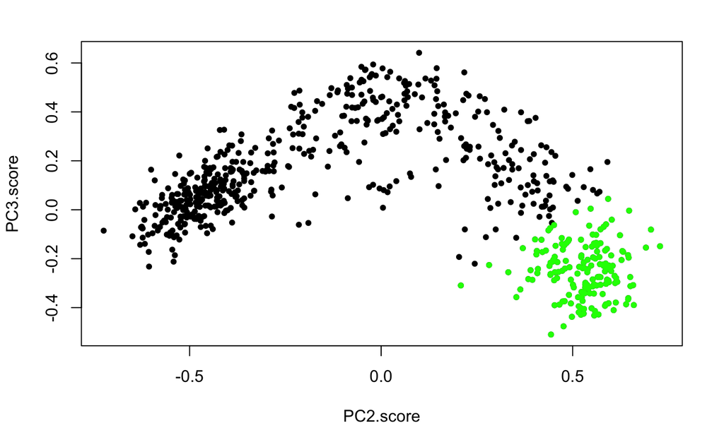

```r
cells.allr3.valve = pc.scores[PC3.score < PC2.score + intercept, cell.name]
cells.allr3.rest = pc.scores[PC3.score >= PC2.score + intercept, cell.name]
# verify valve separation
with(pc.scores, plot(PC2.score, PC3.score, pch = 20)) +
  with(pc.scores[cell.name %in% cells.allr3.valve],points(PC2.score, PC3.score, col = 'green', pch = 20 ))
```

# all_r4 (remove 3 immune cells)

PC15 separates 3 contaminating immune cells - remove them (too few cells to study)

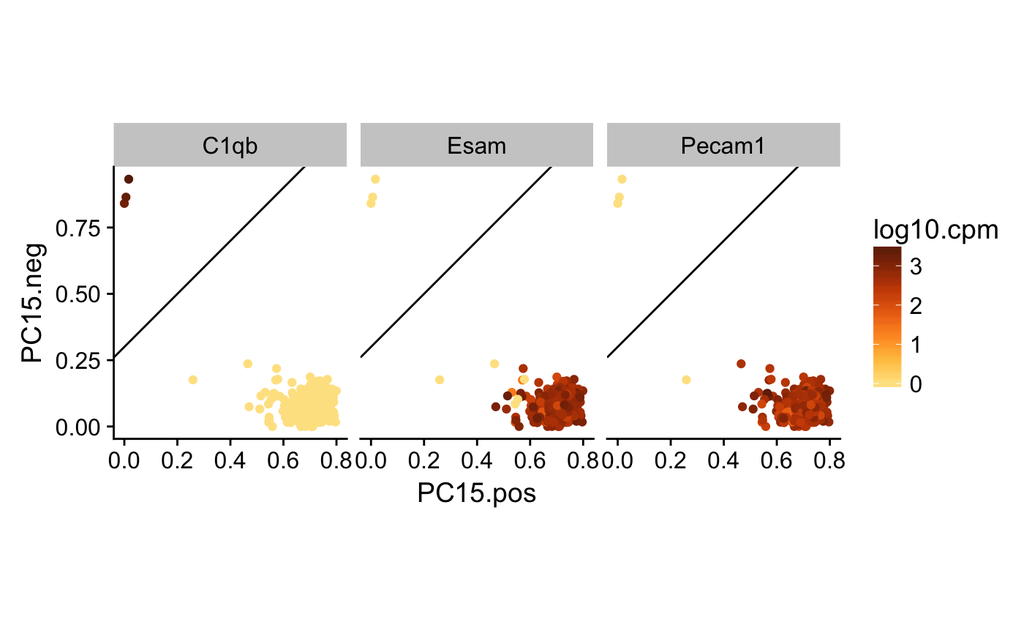

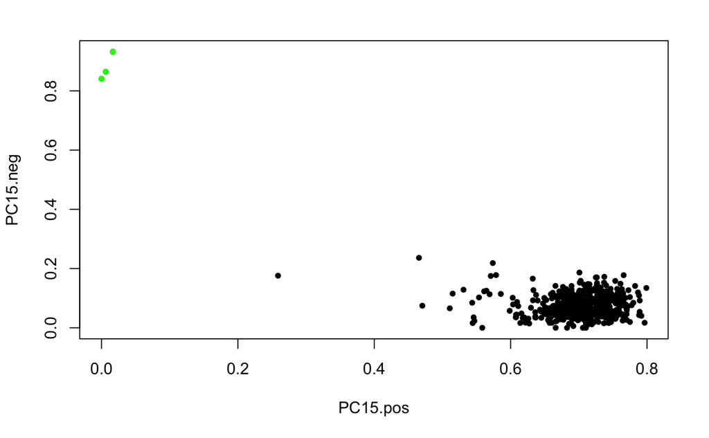

```r
# remove 3 immune cells
pc.scores = fread(paste0(cordir, 'PC_allscores.csv'))
dt.pca.2 = merge(dt.pca[gene %in% c('Pecam1','C1qb','Esam')],
                 pc.scores[,c('cell.name',colnames(pc.scores)[colnames(pc.scores) %like% "PC[0-9]"]), with = F],
                 by = 'cell.name')
cutoff <- -.3
plt=ggplot(dt.pca.2, aes(PC15.pos, PC15.neg, color = log10.cpm)) + geom_point() +
  scale_color_gradientn(colours=brewer.pal(9,'YlOrBr')[3:9]) +
  facet_wrap(~gene) + coord_fixed() +
  geom_abline(intercept = -cutoff)
plt
save_plot('all_r4/all_r4_separation.pdf',plt,ncol=3, nrow=1, base_height = 2.5)
# define the immune cells
cells.allr4.immune = pc.scores[PC15.score < cutoff, cell.name]
cells.allr4.rest = pc.scores[PC15.score >= cutoff, cell.name]
with(pc.scores, plot(PC15.pos, PC15.neg, pch = 20))

with(pc.scores[cell.name %in% cells.allr4.immune],points(PC15.pos, PC15.neg, col = 'green', pch = 20 ))
```

```r
save(cells.allr4.immune, file = 'all_r4/all_r4_immune.RData')
write.table(cells.allr4.immune, file = 'all_r4/all_r4_immune.txt')
save(cells.allr4.rest, file = 'all_r4/all_r4_rest.RData')
write.table(cells.allr4.rest, file = 'all_r4/all_r4_rest.txt')
```

# all_r5 (remove SVv)

PC2 and PC7 separates the Fbln2+ SVv population, which is strongly continous with the A2m+ SVc population. There are also a few cells that appear continuous with the Apln+ CV Plexus population. The SVc and CV Plexus populations also appear strongly continuous with one another.

Separate and remove the SVv population to better analyze the SVc-CV Plexus continuum.

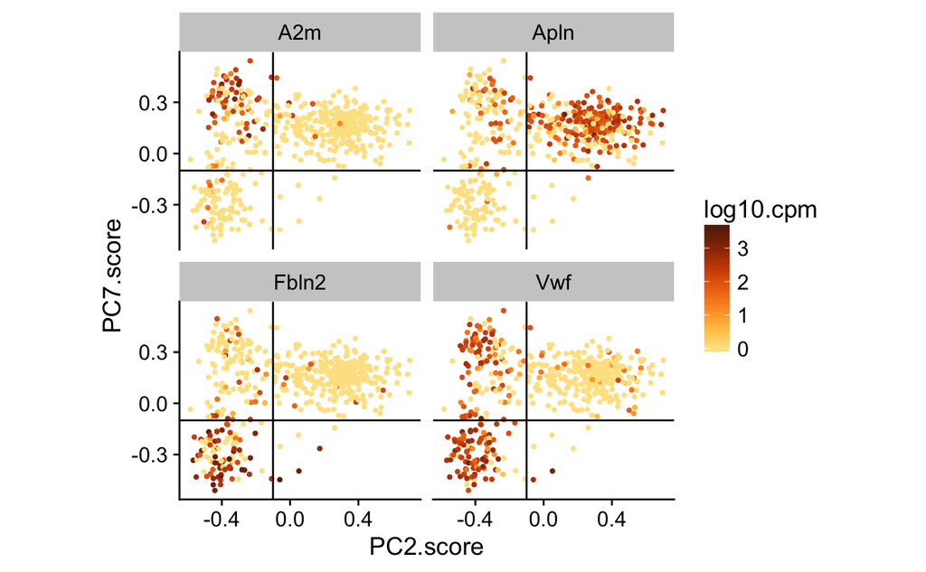

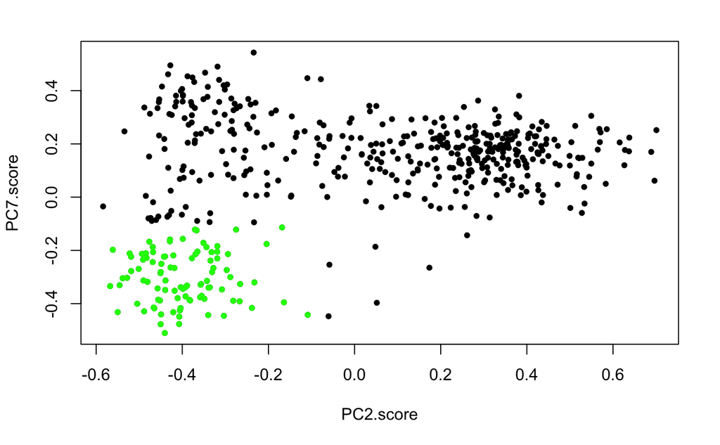

```r
cutoff.pc7 <- -.1
cutoff.pc2 <- -.1
plt=ggplot(dt.pca.2, aes(PC2.score, PC7.score, color = log10.cpm)) + geom_point(size=.8) +
  scale_color_gradientn(colours=brewer.pal(9,'YlOrBr')[3:9]) +
  facet_wrap(~gene) + coord_fixed() +
  geom_hline(yintercept = cutoff.pc7) +
  geom_vline(xintercept = cutoff.pc2)
plt
save_plot('all_r5/all_r5_separation.pdf',plt,ncol=2, nrow=2, base_height = 3)
cells.allr5.SVv = pc.scores[(PC2.score < cutoff.pc2) & (PC7.score < cutoff.pc7), cell.name]
cells.allr5.rest = pc.scores[!cell.name %in% cells.allr5.SVv, cell.name]
save(cells.allr5.SVv, file = 'all_r5/all_r5_SVv.RData')
write.table(cells.allr5.SVv, file = 'all_r5/all_r5_SVv.txt')
save(cells.allr5.rest, file = 'all_r5/all_r5_rest.RData')
write.table(cells.allr5.rest, file = 'all_r5/all_r5_rest.txt')
with(pc.scores, plot(PC2.score, PC7.score, pch = 20))

with(pc.scores[cell.name %in% cells.allr5.SVv],points(PC2.score, PC7.score, col = 'green', pch = 20 ))
```